**City College of San Francisco**

MATH 108 - Foundations of Data Science

# Lecture 12: Table Examples

Associated Textbook Sections: [8.5](https://inferentialthinking.com/chapters/08/5/Bike_Sharing_in_the_Bay_Area.html)

## Set Up the Notebook

```python
from datascience import *
import numpy as np
%matplotlib inline
import matplotlib.pyplot as plots
plots.style.use('fivethirtyeight')
import warnings
warnings.simplefilter(action='ignore',category=np.VisibleDeprecationWarning)
```

# Table of Contents

## Table Examples

### Demo: Billionaires

Load the `billionairs.csv` data and visualize the distribution of `'citizenship'` and `'industry'`.

```python
billionaires = Table.read_table('billionaires.csv')
billionaires
```

| name | net worth | citizenship | industry |
| --- | --- | --- | --- |
| Jeff Bezos | 115739645754 | United States | Technology |
| Bill Gates | 115488591742 | United States | Technology |
| Bernard Arnault | 102244728472 | France | Consumer |
| Warren Buffett | 89408278188 | United States | Diversified |
| Mark Zuckerberg | 83053011017 | United States | Technology |
| Amancio Ortega | 73839366133 | Spain | Retail |
| Larry Page | 69933009751 | United States | Technology |
| Sergey Brin | 67825250468 | United States | Technology |
| Carlos Slim | 62527178289 | Mexico | Diversified |
| Charles Koch | 61046822719 | United States | Industrial |

... (490 rows omitted)

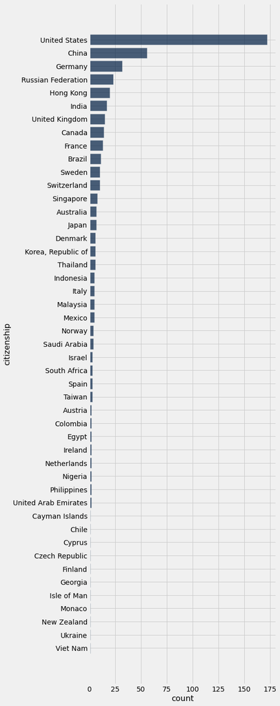

```python
billionaires.group('citizenship')\
            .sort('count', descending=True)\
            .barh('citizenship')
```

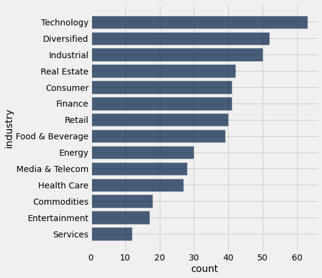

```python
billionaires.group('industry')\
            .sort('count', descending=True)\
            .barh('industry')
```

Cross-classify the billionaires based on industry and citizenship.

```python
billionaires.pivot('industry', 'citizenship').show()
```

| citizenship | Commodities | Consumer | Diversified | Energy | Entertainment | Finance | Food & Beverage | Health Care | Industrial | Media & Telecom | Real Estate | Retail | Services | Technology |
| --- | --- | --- | --- | --- | --- | --- | --- | --- | --- | --- | --- | --- | --- | --- |
| Australia | 2 | 0 | 0 | 0 | 0 | 0 | 0 | 0 | 1 | 0 | 2 | 0 | 0 | 2 |
| Austria | 0 | 0 | 0 | 0 | 1 | 0 | 1 | 0 | 0 | 0 | 0 | 0 | 0 | 0 |
| Brazil | 1 | 0 | 0 | 0 | 0 | 5 | 3 | 0 | 1 | 0 | 0 | 0 | 0 | 1 |
| Canada | 1 | 0 | 0 | 1 | 0 | 0 | 1 | 0 | 0 | 7 | 0 | 3 | 0 | 1 |
| Cayman Islands | 0 | 0 | 0 | 0 | 0 | 1 | 0 | 0 | 0 | 0 | 0 | 0 | 0 | 0 |
| Chile | 1 | 0 | 0 | 0 | 0 | 0 | 0 | 0 | 0 | 0 | 0 | 0 | 0 | 0 |
| China | 1 | 6 | 2 | 3 | 0 | 1 | 5 | 6 | 4 | 0 | 7 | 2 | 4 | 15 |
| Colombia | 0 | 0 | 0 | 0 | 0 | 1 | 1 | 0 | 0 | 0 | 0 | 0 | 0 | 0 |
| Cyprus | 0 | 0 | 0 | 0 | 0 | 0 | 0 | 0 | 1 | 0 | 0 | 0 | 0 | 0 |
| Czech Republic | 0 | 0 | 1 | 0 | 0 | 0 | 0 | 0 | 0 | 0 | 0 | 0 | 0 | 0 |
| Denmark | 0 | 4 | 0 | 0 | 0 | 0 | 0 | 1 | 0 | 0 | 0 | 1 | 0 | 0 |
| Egypt | 0 | 0 | 0 | 0 | 0 | 0 | 0 | 0 | 1 | 1 | 0 | 0 | 0 | 0 |
| Finland | 0 | 0 | 0 | 0 | 0 | 0 | 0 | 0 | 1 | 0 | 0 | 0 | 0 | 0 |
| France | 0 | 5 | 1 | 0 | 0 | 0 | 3 | 1 | 0 | 1 | 0 | 1 | 0 | 1 |
| Georgia | 0 | 0 | 1 | 0 | 0 | 0 | 0 | 0 | 0 | 0 | 0 | 0 | 0 | 0 |
| Germany | 0 | 3 | 1 | 1 | 0 | 0 | 2 | 3 | 8 | 2 | 1 | 6 | 0 | 5 |
| Hong Kong | 0 | 0 | 0 | 2 | 3 | 0 | 1 | 1 | 1 | 1 | 10 | 1 | 0 | 0 |
| India | 3 | 0 | 2 | 1 | 0 | 1 | 0 | 2 | 3 | 1 | 1 | 1 | 0 | 2 |
| Indonesia | 0 | 1 | 2 | 1 | 0 | 0 | 0 | 0 | 1 | 0 | 0 | 0 | 0 | 0 |
| Ireland | 0 | 0 | 0 | 0 | 0 | 1 | 0 | 0 | 1 | 0 | 0 | 0 | 0 | 0 |
| Isle of Man | 0 | 0 | 0 | 0 | 1 | 0 | 0 | 0 | 0 | 0 | 0 | 0 | 0 | 0 |
| Israel | 0 | 0 | 2 | 0 | 0 | 0 | 0 | 0 | 0 | 0 | 0 | 0 | 1 | 0 |
| Italy | 1 | 2 | 0 | 0 | 0 | 0 | 1 | 0 | 0 | 1 | 0 | 0 | 0 | 0 |
| Japan | 0 | 1 | 0 | 0 | 0 | 0 | 0 | 0 | 1 | 1 | 0 | 2 | 0 | 2 |
| Korea, Republic of | 0 | 1 | 2 | 0 | 0 | 0 | 0 | 1 | 1 | 0 | 0 | 0 | 0 | 1 |
| Malaysia | 0 | 0 | 3 | 0 | 1 | 1 | 0 | 0 | 0 | 0 | 0 | 0 | 0 | 0 |
| Mexico | 2 | 0 | 2 | 0 | 0 | 0 | 1 | 0 | 0 | 0 | 0 | 0 | 0 | 0 |
| Monaco | 0 | 0 | 0 | 0 | 0 | 0 | 0 | 0 | 0 | 0 | 0 | 1 | 0 | 0 |
| Netherlands | 0 | 0 | 0 | 0 | 0 | 0 | 1 | 0 | 0 | 0 | 0 | 1 | 0 | 0 |
| New Zealand | 0 | 0 | 0 | 0 | 0 | 1 | 0 | 0 | 0 | 0 | 0 | 0 | 0 | 0 |
| Nigeria | 0 | 0 | 0 | 0 | 0 | 0 | 0 | 0 | 1 | 1 | 0 | 0 | 0 | 0 |
| Norway | 0 | 1 | 0 | 0 | 0 | 0 | 1 | 0 | 0 | 0 | 1 | 1 | 0 | 0 |
| Philippines | 0 | 0 | 1 | 0 | 0 | 0 | 0 | 0 | 0 | 0 | 0 | 0 | 1 | 0 |
| Russian Federation | 3 | 0 | 9 | 3 | 0 | 0 | 0 | 0 | 8 | 0 | 0 | 0 | 0 | 0 |
| Saudi Arabia | 0 | 1 | 1 | 1 | 0 | 0 | 0 | 0 | 0 | 0 | 0 | 1 | 0 | 0 |
| Singapore | 0 | 0 | 0 | 0 | 0 | 1 | 2 | 1 | 1 | 0 | 3 | 0 | 0 | 0 |
| South Africa | 0 | 0 | 2 | 0 | 0 | 0 | 1 | 0 | 0 | 0 | 0 | 0 | 0 | 0 |
| Spain | 0 | 0 | 0 | 0 | 0 | 0 | 0 | 0 | 1 | 0 | 0 | 2 | 0 | 0 |
| Sweden | 0 | 0 | 3 | 0 | 0 | 0 | 0 | 1 | 1 | 0 | 1 | 1 | 3 | 0 |
| Switzerland | 0 | 0 | 2 | 0 | 0 | 0 | 0 | 4 | 3 | 0 | 0 | 0 | 1 | 0 |
| Taiwan | 0 | 0 | 0 | 0 | 0 | 0 | 1 | 0 | 1 | 0 | 0 | 0 | 0 | 1 |
| Thailand | 0 | 0 | 3 | 1 | 0 | 0 | 1 | 0 | 0 | 0 | 0 | 1 | 0 | 0 |
| Ukraine | 0 | 0 | 0 | 0 | 0 | 0 | 0 | 0 | 1 | 0 | 0 | 0 | 0 | 0 |
| United Arab Emirates | 0 | 0 | 0 | 0 | 0 | 0 | 1 | 0 | 0 | 0 | 1 | 0 | 0 | 0 |
| United Kingdom | 0 | 2 | 4 | 0 | 2 | 0 | 0 | 0 | 4 | 0 | 2 | 1 | 0 | 0 |
| United States | 3 | 14 | 8 | 16 | 9 | 28 | 12 | 6 | 4 | 12 | 12 | 14 | 2 | 32 |
| Viet Nam | 0 | 0 | 0 | 0 | 0 | 0 | 0 | 0 | 0 | 0 | 1 | 0 | 0 | 0 |

```python
billionaires.pivot('industry', 'citizenship', 'net worth', np.average).show()
```

| citizenship | Commodities | Consumer | Diversified | Energy | Entertainment | Finance | Food & Beverage | Health Care | Industrial | Media & Telecom | Real Estate | Retail | Services | Technology |
| --- | --- | --- | --- | --- | --- | --- | --- | --- | --- | --- | --- | --- | --- | --- |
| Australia | 1.51032e+10 | 0 | 0 | 0 | 0 | 0 | 0 | 0 | 6.566e+09 | 0 | 8.06122e+09 | 0 | 0 | 9.33599e+09 |
| Austria | 0 | 0 | 0 | 0 | 6.50918e+09 | 0 | 1.22513e+10 | 0 | 0 | 0 | 0 | 0 | 0 | 0 |
| Brazil | 5.36402e+09 | 0 | 0 | 0 | 0 | 8.45913e+09 | 1.4474e+10 | 0 | 5.36317e+09 | 0 | 0 | 0 | 0 | 1.18408e+10 |
| Canada | 5.50562e+09 | 0 | 0 | 5.53757e+09 | 0 | 0 | 5.19606e+09 | 0 | 0 | 6.63592e+09 | 0 | 6.22065e+09 | 0 | 1.22102e+10 |
| Cayman Islands | 0 | 0 | 0 | 0 | 0 | 5.97691e+09 | 0 | 0 | 0 | 0 | 0 | 0 | 0 | 0 |
| Chile | 1.46519e+10 | 0 | 0 | 0 | 0 | 0 | 0 | 0 | 0 | 0 | 0 | 0 | 0 | 0 |
| China | 4.42124e+09 | 9.21044e+09 | 7.70055e+09 | 6.45323e+09 | 0 | 5.10718e+09 | 8.55566e+09 | 9.43534e+09 | 8.20169e+09 | 0 | 1.43895e+10 | 5.94047e+09 | 7.21169e+09 | 1.5477e+10 |
| Colombia | 0 | 0 | 0 | 0 | 0 | 1.18406e+10 | 1.33773e+10 | 0 | 0 | 0 | 0 | 0 | 0 | 0 |
| Cyprus | 0 | 0 | 0 | 0 | 0 | 0 | 0 | 0 | 8.7983e+09 | 0 | 0 | 0 | 0 | 0 |
| Czech Republic | 0 | 0 | 1.28909e+10 | 0 | 0 | 0 | 0 | 0 | 0 | 0 | 0 | 0 | 0 | 0 |
| Denmark | 0 | 5.56266e+09 | 0 | 0 | 0 | 0 | 0 | 6.95344e+09 | 0 | 0 | 0 | 6.08027e+09 | 0 | 0 |
| Egypt | 0 | 0 | 0 | 0 | 0 | 0 | 0 | 0 | 6.85247e+09 | 5.11588e+09 | 0 | 0 | 0 | 0 |
| Finland | 0 | 0 | 0 | 0 | 0 | 0 | 0 | 0 | 5.51668e+09 | 0 | 0 | 0 | 0 | 0 |
| France | 0 | 5.26302e+10 | 4.53698e+09 | 0 | 0 | 0 | 5.85616e+09 | 5.8782e+09 | 0 | 1.22486e+10 | 0 | 4.92609e+09 | 0 | 4.7481e+09 |
| Georgia | 0 | 0 | 5.545e+09 | 0 | 0 | 0 | 0 | 0 | 0 | 0 | 0 | 0 | 0 | 0 |
| Germany | 0 | 5.51101e+09 | 9.3979e+09 | 7.09577e+09 | 0 | 0 | 5.08604e+09 | 4.96598e+09 | 1.30516e+10 | 4.89043e+09 | 6.04824e+09 | 1.17592e+10 | 0 | 8.83286e+09 |
| Hong Kong | 0 | 0 | 0 | 8.89633e+09 | 8.91822e+09 | 0 | 1.62133e+10 | 8.84777e+09 | 1.10092e+10 | 4.83692e+09 | 1.24636e+10 | 1.72351e+10 | 0 | 0 |
| India | 8.95484e+09 | 0 | 6.29424e+09 | 5.88415e+10 | 0 | 1.4438e+10 | 0 | 8.36402e+09 | 7.33444e+09 | 9.30361e+09 | 6.58632e+09 | 1.02379e+10 | 0 | 1.76251e+10 |
| Indonesia | 0 | 8.52887e+09 | 1.74304e+10 | 8.13506e+09 | 0 | 0 | 0 | 0 | 4.96773e+09 | 0 | 0 | 0 | 0 | 0 |
| Ireland | 0 | 0 | 0 | 0 | 0 | 8.31946e+09 | 0 | 0 | 2.20122e+10 | 0 | 0 | 0 | 0 | 0 |
| Isle of Man | 0 | 0 | 0 | 0 | 4.5525e+09 | 0 | 0 | 0 | 0 | 0 | 0 | 0 | 0 | 0 |
| Israel | 0 | 0 | 6.49447e+09 | 0 | 0 | 0 | 0 | 0 | 0 | 0 | 0 | 0 | 1.14832e+10 | 0 |
| Italy | 9.09765e+09 | 1.61224e+10 | 0 | 0 | 0 | 0 | 3.23492e+10 | 0 | 0 | 8.11379e+09 | 0 | 0 | 0 | 0 |
| Japan | 0 | 6.52207e+09 | 0 | 0 | 0 | 0 | 0 | 0 | 5.72139e+09 | 7.24711e+09 | 0 | 1.71299e+10 | 0 | 1.84936e+10 |
| Korea, Republic of | 0 | 4.66897e+09 | 1.39286e+10 | 0 | 0 | 0 | 0 | 4.93989e+09 | 4.63585e+09 | 0 | 0 | 0 | 0 | 5.12293e+09 |
| Malaysia | 0 | 0 | 8.94425e+09 | 0 | 5.11113e+09 | 6.45638e+09 | 0 | 0 | 0 | 0 | 0 | 0 | 0 | 0 |
| Mexico | 1.0223e+10 | 0 | 3.84918e+10 | 0 | 0 | 0 | 6.3551e+09 | 0 | 0 | 0 | 0 | 0 | 0 | 0 |
| Monaco | 0 | 0 | 0 | 0 | 0 | 0 | 0 | 0 | 0 | 0 | 0 | 1.01733e+10 | 0 | 0 |
| Netherlands | 0 | 0 | 0 | 0 | 0 | 0 | 1.64545e+10 | 0 | 0 | 0 | 0 | 4.78639e+09 | 0 | 0 |
| New Zealand | 0 | 0 | 0 | 0 | 0 | 7.07147e+09 | 0 | 0 | 0 | 0 | 0 | 0 | 0 | 0 |
| Nigeria | 0 | 0 | 0 | 0 | 0 | 0 | 0 | 0 | 1.65059e+10 | 4.71108e+09 | 0 | 0 | 0 | 0 |
| Norway | 0 | 4.41483e+09 | 0 | 0 | 0 | 0 | 5.42177e+09 | 0 | 0 | 0 | 6.43707e+09 | 4.92842e+09 | 0 | 0 |
| Philippines | 0 | 0 | 6.81703e+09 | 0 | 0 | 0 | 0 | 0 | 0 | 0 | 0 | 0 | 4.69306e+09 | 0 |
| Russian Federation | 1.37692e+10 | 0 | 1.19283e+10 | 1.90232e+10 | 0 | 0 | 0 | 0 | 1.22328e+10 | 0 | 0 | 0 | 0 | 0 |
| Saudi Arabia | 0 | 5.31765e+09 | 1.48343e+10 | 8.93135e+09 | 0 | 0 | 0 | 0 | 0 | 0 | 0 | 7.19149e+09 | 0 | 0 |
| Singapore | 0 | 0 | 0 | 0 | 0 | 9.19069e+09 | 6.95356e+09 | 9.57564e+09 | 1.078e+10 | 0 | 6.1171e+09 | 0 | 0 | 0 |
| South Africa | 0 | 0 | 7.29722e+09 | 0 | 0 | 0 | 6.15496e+09 | 0 | 0 | 0 | 0 | 0 | 0 | 0 |
| Spain | 0 | 0 | 0 | 0 | 0 | 0 | 0 | 0 | 5.69802e+09 | 0 | 0 | 4.07725e+10 | 0 | 0 |
| Sweden | 0 | 0 | 8.28529e+09 | 0 | 0 | 0 | 0 | 5.45205e+09 | 8.25228e+09 | 0 | 5.38629e+09 | 1.97752e+10 | 6.90218e+09 | 0 |
| Switzerland | 0 | 0 | 1.13224e+10 | 0 | 0 | 0 | 0 | 6.02117e+09 | 5.73015e+09 | 0 | 0 | 0 | 9.39938e+09 | 0 |
| Taiwan | 0 | 0 | 0 | 0 | 0 | 0 | 6.77883e+09 | 0 | 5.84739e+09 | 0 | 0 | 0 | 0 | 4.54633e+09 |
| Thailand | 0 | 0 | 5.1247e+09 | 1.01755e+10 | 0 | 0 | 1.82237e+10 | 0 | 0 | 0 | 0 | 5.93372e+09 | 0 | 0 |
| Ukraine | 0 | 0 | 0 | 0 | 0 | 0 | 0 | 0 | 6.06683e+09 | 0 | 0 | 0 | 0 | 0 |
| United Arab Emirates | 0 | 0 | 0 | 0 | 0 | 0 | 5.55834e+09 | 0 | 0 | 0 | 6.70646e+09 | 0 | 0 | 0 |
| United Kingdom | 0 | 9.65877e+09 | 6.2167e+09 | 0 | 5.2658e+09 | 0 | 0 | 0 | 8.74961e+09 | 0 | 1.03635e+10 | 5.59222e+09 | 0 | 0 |
| United States | 5.13849e+09 | 9.61956e+09 | 2.17615e+10 | 6.80099e+09 | 1.05302e+10 | 9.03037e+09 | 1.38849e+10 | 1.00891e+10 | 3.71755e+10 | 9.79877e+09 | 7.74918e+09 | 1.74903e+10 | 5.20461e+09 | 2.68271e+10 |
| Viet Nam | 0 | 0 | 0 | 0 | 0 | 0 | 0 | 0 | 0 | 0 | 9.07756e+09 | 0 | 0 | 0 |

Load the `countries.csv` data, and join that data with the data in the billionaires table based on the citizenship country of the billionaire.

```python
countries = Table.read_table('countries.csv')
countries
```

| Continent | Country |
| --- | --- |
| Africa | Algeria |
| Africa | Angola |
| Africa | Benin |
| Africa | Botswana |
| Africa | Burkina |
| Africa | Burundi |
| Africa | Cameroon |
| Africa | Cape Verde |
| Africa | Central African Republic |
| Africa | Chad |

... (188 rows omitted)

```python
billionaires = billionaires.join('citizenship', countries, 'Country')
billionaires
```

| citizenship | name | net worth | industry | Continent |
| --- | --- | --- | --- | --- |
| Australia | Gina Rinehart | 19984845036 | Commodities | Oceania |
| Australia | Andrew Forrest | 10221458789 | Commodities | Oceania |
| Australia | Harry Triguboff | 9467000000 | Real Estate | Oceania |
| Australia | Scott Farquhar | 9335988154 | Technology | Oceania |
| Australia | Mike Cannon-Brookes | 9335988154 | Technology | Oceania |
| Australia | Frank Lowy | 6655432824 | Real Estate | Oceania |
| Australia | Anthony Pratt | 6566000000 | Industrial | Oceania |
| Austria | Dietrich Mateschitz | 12251315379 | Food & Beverage | Europe |
| Austria | Johann Graf | 6509183360 | Entertainment | Europe |
| Brazil | Jorge Paulo Lemann | 23056345424 | Food & Beverage | South America |

... (490 rows omitted)

Cross-classify the billionaires based on industry and continent values.

```python
billionaires.pivot('industry', 'Continent', 'net worth', np.average)
```

| Continent | Commodities | Consumer | Diversified | Energy | Entertainment | Finance | Food & Beverage | Health Care | Industrial | Media & Telecom | Real Estate | Retail | Services | Technology |
| --- | --- | --- | --- | --- | --- | --- | --- | --- | --- | --- | --- | --- | --- | --- |
| Africa | 0 | 0 | 7.29722e+09 | 0 | 0 | 0 | 6.15496e+09 | 0 | 1.16792e+10 | 4.91348e+09 | 0 | 0 | 0 | 0 |
| Asia | 1.03705e+10 | 8.03002e+09 | 1.01818e+10 | 1.50254e+10 | 7.96645e+09 | 8.79806e+09 | 9.40541e+09 | 8.79122e+09 | 9.31591e+09 | 7.12921e+09 | 1.15689e+10 | 1.08424e+10 | 7.50383e+09 | 1.49553e+10 |
| Europe | 9.09765e+09 | 2.10536e+10 | 8.05679e+09 | 7.09577e+09 | 5.39832e+09 | 8.31946e+09 | 1.04686e+10 | 5.72663e+09 | 1.01403e+10 | 7.5358e+09 | 7.71972e+09 | 1.38908e+10 | 7.52648e+09 | 8.15207e+09 |
| North America | 6.89452e+09 | 9.61956e+09 | 2.51075e+10 | 6.72667e+09 | 1.05302e+10 | 8.92508e+09 | 1.27264e+10 | 1.00891e+10 | 3.71755e+10 | 8.63351e+09 | 7.74918e+09 | 1.55015e+10 | 5.20461e+09 | 2.63841e+10 |
| Oceania | 1.51032e+10 | 0 | 0 | 0 | 0 | 7.07147e+09 | 0 | 0 | 6.566e+09 | 0 | 8.06122e+09 | 0 | 0 | 9.33599e+09 |
| South America | 1.00079e+10 | 0 | 0 | 0 | 0 | 9.0227e+09 | 1.41998e+10 | 0 | 5.36317e+09 | 0 | 0 | 0 | 0 | 1.18408e+10 |

Load the `ceo.csv` data and visualize the distribution of values of `'amount'` that represent the contribution amount toward the give party.

```python
ceos = Table.read_table('ceo.csv')
ceos.sort('amount', descending=True)
```

| company | ceo | party | amount |
| --- | --- | --- | --- |
| Hewlett-Packard Co | Margaret Whitman | 200 | 1.25273e+08 |
| Caterpillar Inc | Jon Huntsman | 200 | 1.27686e+07 |
| Las Vegas Sands | Sheldon Adelson | 200 | 6.20425e+06 |
| Las Vegas Sands | Sheldon g Adelson | 200 | 5e+06 |
| Visteon | Harry Wilson | 200 | 4.0304e+06 |
| Yahoo! Inc | Daniel Loeb | 200 | 2.51255e+06 |
| YRC Worldwide Inc | Matthew Doheny | 200 | 1.47332e+06 |
| Charles Schwab Corp | Charles Schwab | 200 | 1.2364e+06 |
| DTE Energy | James Nicholson | 200 | 986850 |
| Limited Brance | Leslie Wexner | 200 | 942800 |

... (4677 rows omitted)

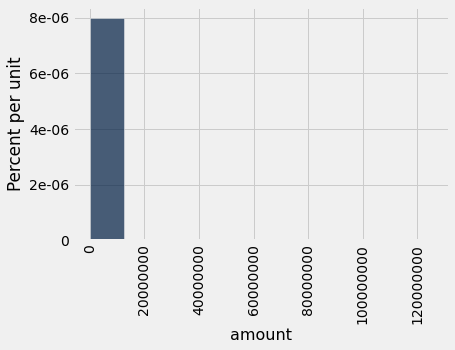

```python
ceos.hist('amount')
```

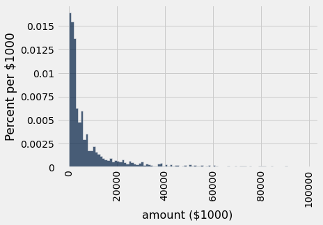

```python
ceos.hist('amount', bins=np.arange(0, 1e5, 1e3), unit='$1000')
```

Join the the CEO data with the billionaires data based on `'name'` and `'ceo'`.

```python
b_donations = billionaires.join('name', ceos, 'ceo')
b_donations.sort('net worth', descending=True)
```

[output not shown]

... (46 rows omitted)

Visualize the relationship between the values of `'net worth'` and `'amount'` where the `'amount'` values are less than 6,000,000.

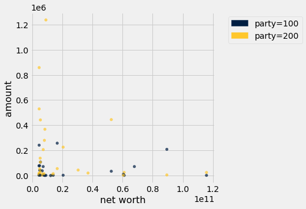

```python
b_donations.where('amount', are.below(6e6)).scatter('net worth', 'amount', group='party')
```

```python
b_donations.group('party')
```

| party | count |
| --- | --- |
| 100 | 25 |
| 200 | 31 |

Create a table with the columns:

```
'name',
 'citizenship',
 'net worth',
 'industry',
 'Continent',
 'company',
 'party',
 'amount',
 'Contribution%'
```

`'Contributions%'` represents the percentage of the billionaire's net worth contributed to the specified party.

```python
donation_prop = b_donations.column('amount') / b_donations.column('net worth')
b_donations = b_donations.with_column('Contributions%', donation_prop)
b_donations = b_donations.sort('amount', descending=True)
b_donations.set_format('Contributions%', PercentFormatter)
```

| name | citizenship | net worth | industry | Continent | company | party | amount | Contributions% |
| --- | --- | --- | --- | --- | --- | --- | --- | --- |
| Sheldon Adelson | United States | 38008857087 | Entertainment | North America | Las Vegas Sands | 200 | 6.20425e+06 | 0.02% |
| Charles Schwab | United States | 9063879795 | Finance | North America | Charles Schwab Corp | 200 | 1.2364e+06 | 0.01% |
| Charles Johnson | United States | 4587892463 | Finance | North America | Franklin Resources | 200 | 858000 | 0.02% |
| Kelcy Warren | United States | 4595072119 | Energy | North America | Energy Transfer | 200 | 529886 | 0.01% |
| Jim Walton | United States | 52493506006 | Retail | North America | Wal-Mart Stores Inc | 200 | 444700 | 0.00% |
| Ray Hunt | United States | 5421192714 | Energy | North America | PepsiCo Inc | 200 | 442364 | 0.01% |
| Richard Kinder | United States | 8398076785 | Energy | North America | Kinder Morgan | 200 | 368000 | 0.00% |
| John Malone | United States | 8069296402 | Media & Telecom | North America | Liberty Global | 200 | 280050 | 0.00% |
| Eric Schmidt | United States | 16579148665 | Technology | North America | google | 100 | 257300 | 0.00% |
| Reed Hastings | United States | 4569628489 | Technology | North America | Facebook | 100 | 241700 | 0.01% |

... (46 rows omitted)

### Demo: Meteorites

Load and explore the `meteorites_na.csv` data.

```python
meteorites = Table.read_table('meteorites_na.csv')
meteorites
```

| name | class | mass | how | year | lat | lon |
| --- | --- | --- | --- | --- | --- | --- |
| Abee | EH4 | 107000 | Fell | 1952 | 54.2167 | -113 |
| Acapulco | Acapulcoite | 1914 | Fell | 1976 | 16.8833 | -99.9 |
| Allegan | H5 | 32000 | Fell | 1899 | 42.5333 | -85.8833 |
| Allende | CV3 | 2e+06 | Fell | 1969 | 26.9667 | -105.317 |
| Andover | L6 | 3200 | Fell | 1898 | 44.6167 | -70.75 |
| Archie | H6 | 5070 | Fell | 1932 | 38.5 | -94.3 |
| Ash Creek | L6 | 9500 | Fell | 2009 | 31.805 | -97.01 |
| Atemajac | L6 | 94.2 | Fell | 1896 | 20.0667 | -103.667 |
| Athens | LL6 | 265 | Fell | 1933 | 34.75 | -87 |
| Atoka | L6 | 1384.2 | Fell | 1945 | 34.3167 | -96.15 |

... (1797 rows omitted)

```python
meteorites.group('class').sort('count', descending=True)
```

| class | count |
| --- | --- |
| H5 | 293 |
| L6 | 278 |
| H4 | 186 |
| L5 | 136 |
| H6 | 132 |
| Iron, IIIAB | 124 |
| L4 | 53 |
| OC | 43 |
| Iron, IIAB | 42 |
| Iron, IAB-MG | 37 |

... (118 rows omitted)

```python
meteorites.group('how')
```

| how | count |
| --- | --- |
| Fell | 181 |
| Found | 1626 |

```python
meteorites.group('how', np.average)
```

| how | name average | class average | mass average | year average | lat average | lon average |
| --- | --- | --- | --- | --- | --- | --- |
| Fell |  |  | 38316.9 | 1926.62 | 37.2264 | -93.3681 |
| Found |  |  | 132638 | 1958.22 | 36.206 | -103.928 |

Visualize the distributions of the `'year'` values for each value of `'how'`.

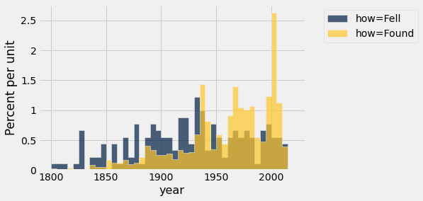

```python
meteorites.hist('year', bins=np.arange(1800, 2022, 5), group='how')
```

Visualize the relationship between `'year'` and `'mass'`. Consider ignoring some of the outliers.

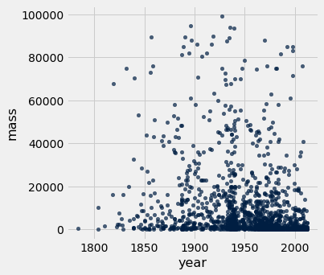

```python
meteorites.where('mass', are.below(1e5)).scatter('year', 'mass')
```

Create tables for the fell and found meteorites are the year 1950.

```python
new_fell = meteorites.where('how', 'Fell').where('year', are.above(1950))
new_found = meteorites.where('how', 'Found').where('year', are.above(1950))
new_found
```

| name | class | mass | how | year | lat | lon |
| --- | --- | --- | --- | --- | --- | --- |
| Abajo | H5 | 331 | Found | 1982 | 26.8 | -105.417 |
| Abbott | H3-6 | 21100 | Found | 1951 | 36.3 | -104.283 |
| Ackerly | L5 | 3046 | Found | 1995 | 32.5903 | -101.772 |
| Acomita | Pallasite, PMG | 3956 | Found | 1962 | 35.05 | -107.567 |
| Acuña | Iron, IIIAB | 217700 | Found | 1981 | 29.3167 | -100.967 |
| Akron (1961) | L6 | 4000 | Found | 1961 | 40.15 | -103.167 |
| Albion | Iron, IVA | 12280 | Found | 1966 | 46.8333 | -117.25 |
| Aldama (a) | Iron, IIIAB | 11000 | Found | 1985 | 28.8333 | -105.867 |
| Aldama (b) | H5 | 66.5 | Found | 1996 | 25.05 | -106 |
| Alkali | H6 | 30.47 | Found | 1998 | 37.8667 | -117.4 |

... (1016 rows omitted)

### Demo: Maps

Visualize the locations of the fell and found meteorites after 1950.

```python
Marker.map_table(new_fell.select('lat', 'lon', 'name'))
```

Make this Notebook Trusted to load map: File -> Trust Notebook

[interactive chart not shown]

### Demo: Bikes

Load the `trip.csv` data.

- *If you loaded the meteorites dataset above, now might be a good time to restart your kernel, run the cell at the top of the notebook, then come back here.*
- *The bike datasets in this section is big, and could lead to kernel crashes.*

```python
from datascience import *
import numpy as np
%matplotlib inline
import matplotlib.pyplot as plots
plots.style.use('fivethirtyeight')
import warnings
warnings.simplefilter(action='ignore',category=np.VisibleDeprecationWarning)
```

```python
trip = Table.read_table('trip.csv')
trip
```

| Trip ID | Duration | Start Date | Start Station | Start Terminal | End Date | End Station | End Terminal | Bike # | Subscriber Type | Zip Code |
| --- | --- | --- | --- | --- | --- | --- | --- | --- | --- | --- |
| 913460 | 765 | 8/31/2015 23:26 | Harry Bridges Plaza (Ferry Building) | 50 | 8/31/2015 23:39 | San Francisco Caltrain (Townsend at 4th) | 70 | 288 | Subscriber | 2139 |
| 913459 | 1036 | 8/31/2015 23:11 | San Antonio Shopping Center | 31 | 8/31/2015 23:28 | Mountain View City Hall | 27 | 35 | Subscriber | 95032 |
| 913455 | 307 | 8/31/2015 23:13 | Post at Kearny | 47 | 8/31/2015 23:18 | 2nd at South Park | 64 | 468 | Subscriber | 94107 |
| 913454 | 409 | 8/31/2015 23:10 | San Jose City Hall | 10 | 8/31/2015 23:17 | San Salvador at 1st | 8 | 68 | Subscriber | 95113 |
| 913453 | 789 | 8/31/2015 23:09 | Embarcadero at Folsom | 51 | 8/31/2015 23:22 | Embarcadero at Sansome | 60 | 487 | Customer | 9069 |
| 913452 | 293 | 8/31/2015 23:07 | Yerba Buena Center of the Arts (3rd @ Howard) | 68 | 8/31/2015 23:12 | San Francisco Caltrain (Townsend at 4th) | 70 | 538 | Subscriber | 94118 |
| 913451 | 896 | 8/31/2015 23:07 | Embarcadero at Folsom | 51 | 8/31/2015 23:22 | Embarcadero at Sansome | 60 | 363 | Customer | 92562 |
| 913450 | 255 | 8/31/2015 22:16 | Embarcadero at Sansome | 60 | 8/31/2015 22:20 | Steuart at Market | 74 | 470 | Subscriber | 94111 |
| 913449 | 126 | 8/31/2015 22:12 | Beale at Market | 56 | 8/31/2015 22:15 | Temporary Transbay Terminal (Howard at Beale) | 55 | 439 | Subscriber | 94130 |
| 913448 | 932 | 8/31/2015 21:57 | Post at Kearny | 47 | 8/31/2015 22:12 | South Van Ness at Market | 66 | 472 | Subscriber | 94702 |

... (354142 rows omitted)

Visualize the distribution of trip durations less than 1800 seconds. Use a few different different bins in the visualizations.

```python
trip.sort('Duration', descending=True)
```

| Trip ID | Duration | Start Date | Start Station | Start Terminal | End Date | End Station | End Terminal | Bike # | Subscriber Type | Zip Code |
| --- | --- | --- | --- | --- | --- | --- | --- | --- | --- | --- |
| 568474 | 17270400 | 12/6/2014 21:59 | South Van Ness at Market | 66 | 6/24/2015 20:18 | 2nd at Folsom | 62 | 535 | Customer | 95531 |
| 825850 | 2137000 | 6/28/2015 21:50 | Market at Sansome | 77 | 7/23/2015 15:27 | Yerba Buena Center of the Arts (3rd @ Howard) | 68 | 466 | Customer | 97213 |
| 750192 | 1852590 | 5/2/2015 6:17 | San Antonio Shopping Center | 31 | 5/23/2015 16:53 | Castro Street and El Camino Real | 32 | 680 | Subscriber | 94024 |
| 841176 | 1133540 | 7/10/2015 10:35 | University and Emerson | 35 | 7/23/2015 13:27 | University and Emerson | 35 | 262 | Customer | 94306 |
| 522337 | 720454 | 10/30/2014 8:29 | Redwood City Caltrain Station | 22 | 11/7/2014 15:36 | Stanford in Redwood City | 25 | 692 | Customer | 94010 |
| 774999 | 688899 | 5/20/2015 15:27 | Palo Alto Caltrain Station | 34 | 5/28/2015 14:49 | California Ave Caltrain Station | 36 | 230 | Customer | nil |
| 635260 | 655939 | 2/8/2015 3:05 | San Jose Civic Center | 3 | 2/15/2015 17:17 | SJSU 4th at San Carlos | 12 | 132 | Customer | 89451 |
| 745640 | 611240 | 4/29/2015 9:41 | University and Emerson | 35 | 5/6/2015 11:28 | San Antonio Shopping Center | 31 | 196 | Customer | 81 |
| 635263 | 602338 | 2/8/2015 3:09 | San Jose Civic Center | 3 | 2/15/2015 2:28 | San Jose Civic Center | 3 | 9 | Customer | 89451 |
| 779645 | 594550 | 5/24/2015 13:33 | San Pedro Square | 6 | 5/31/2015 10:42 | San Pedro Square | 6 | 39 | Customer | 95118 |

... (354142 rows omitted)

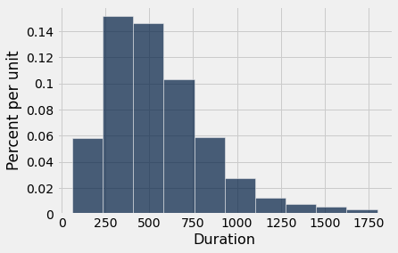

```python
commute = trip.where('Duration', are.below(1800))
commute.hist('Duration')
```

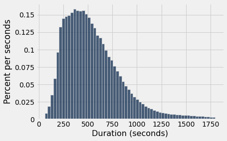

```python
commute.hist('Duration', bins=60, unit='seconds')
```

Group the trips that are less than 1800 seconds by starting station.

```python
starts = commute.group('Start Station').sort('count', descending=True)
starts
```

| Start Station | count |
| --- | --- |
| San Francisco Caltrain (Townsend at 4th) | 25858 |
| San Francisco Caltrain 2 (330 Townsend) | 21523 |
| Harry Bridges Plaza (Ferry Building) | 15543 |
| Temporary Transbay Terminal (Howard at Beale) | 14298 |
| 2nd at Townsend | 13674 |
| Townsend at 7th | 13579 |
| Steuart at Market | 13215 |
| Embarcadero at Sansome | 12842 |
| Market at 10th | 11523 |
| Market at Sansome | 11023 |

... (60 rows omitted)

Cross-classify the trips based on start and end stations.

```python
commute.pivot('Start Station', 'End Station')
```

| End Station | 2nd at Folsom | 2nd at South Park | 2nd at Townsend | 5th at Howard | Adobe on Almaden | Arena Green / SAP Center | Beale at Market | Broadway St at Battery St | California Ave Caltrain Station | Castro Street and El Camino Real | Civic Center BART (7th at Market) | Clay at Battery | Commercial at Montgomery | Cowper at University | Davis at Jackson | Embarcadero at Bryant | Embarcadero at Folsom | Embarcadero at Sansome | Embarcadero at Vallejo | Evelyn Park and Ride | Franklin at Maple | Golden Gate at Polk | Grant Avenue at Columbus Avenue | Harry Bridges Plaza (Ferry Building) | Howard at 2nd | Japantown | MLK Library | Market at 10th | Market at 4th | … |
| --- | --- | --- | --- | --- | --- | --- | --- | --- | --- | --- | --- | --- | --- | --- | --- | --- | --- | --- | --- | --- | --- | --- | --- | --- | --- | --- | --- | --- | --- | --- |
| 2nd at Folsom | 54 | 190 | 554 | 107 | 0 | 0 | 40 | 21 | 0 | 0 | 44 | 78 | 54 | 0 | 9 | 77 | 32 | 41 | 14 | 0 | 0 | 11 | 30 | 416 | 53 | 0 | 0 | 169 | 114 | … |
| 2nd at South Park | 295 | 164 | 71 | 180 | 0 | 0 | 208 | 85 | 0 | 0 | 112 | 87 | 160 | 0 | 37 | 56 | 178 | 83 | 116 | 0 | 0 | 57 | 73 | 574 | 500 | 0 | 0 | 139 | 199 | … |
| 2nd at Townsend | 437 | 151 | 185 | 92 | 0 | 0 | 608 | 350 | 0 | 0 | 80 | 329 | 168 | 0 | 386 | 361 | 658 | 506 | 254 | 0 | 0 | 27 | 315 | 2607 | 295 | 0 | 0 | 110 | 225 | … |
| 5th at Howard | 113 | 177 | 148 | 83 | 0 | 0 | 59 | 130 | 0 | 0 | 203 | 76 | 129 | 0 | 30 | 57 | 49 | 166 | 54 | 0 | 0 | 85 | 78 | 371 | 478 | 0 | 0 | 303 | 158 | … |
| Adobe on Almaden | 0 | 0 | 0 | 0 | 11 | 4 | 0 | 0 | 0 | 0 | 0 | 0 | 0 | 0 | 0 | 0 | 0 | 0 | 0 | 0 | 0 | 0 | 0 | 0 | 0 | 17 | 7 | 0 | 0 | … |
| Arena Green / SAP Center | 0 | 0 | 0 | 0 | 7 | 64 | 0 | 0 | 0 | 0 | 0 | 0 | 0 | 0 | 0 | 0 | 0 | 0 | 0 | 0 | 0 | 0 | 0 | 0 | 0 | 16 | 5 | 0 | 0 | … |
| Beale at Market | 127 | 79 | 183 | 59 | 0 | 0 | 59 | 661 | 0 | 0 | 201 | 75 | 101 | 0 | 247 | 178 | 38 | 590 | 165 | 0 | 0 | 54 | 435 | 57 | 72 | 0 | 0 | 286 | 236 | … |
| Broadway St at Battery St | 67 | 89 | 279 | 119 | 0 | 0 | 1022 | 110 | 0 | 0 | 62 | 283 | 226 | 0 | 191 | 198 | 79 | 231 | 35 | 0 | 0 | 5 | 70 | 168 | 49 | 0 | 0 | 32 | 97 | … |
| California Ave Caltrain Station | 0 | 0 | 0 | 0 | 0 | 0 | 0 | 0 | 38 | 1 | 0 | 0 | 0 | 29 | 0 | 0 | 0 | 0 | 0 | 0 | 0 | 0 | 0 | 0 | 0 | 0 | 0 | 0 | 0 | … |
| Castro Street and El Camino Real | 0 | 0 | 0 | 0 | 0 | 0 | 0 | 0 | 0 | 30 | 0 | 0 | 0 | 0 | 0 | 0 | 0 | 0 | 0 | 14 | 0 | 0 | 0 | 0 | 0 | 0 | 0 | 0 | 0 | … |

... (60 rows omitted)

Reduce the table to only include the start and end stations along with the duration of each trip.

```python
duration = trip.select('Start Station', 'End Station', 'Duration')
duration
```

| Start Station | End Station | Duration |
| --- | --- | --- |
| Harry Bridges Plaza (Ferry Building) | San Francisco Caltrain (Townsend at 4th) | 765 |
| San Antonio Shopping Center | Mountain View City Hall | 1036 |
| Post at Kearny | 2nd at South Park | 307 |
| San Jose City Hall | San Salvador at 1st | 409 |
| Embarcadero at Folsom | Embarcadero at Sansome | 789 |
| Yerba Buena Center of the Arts (3rd @ Howard) | San Francisco Caltrain (Townsend at 4th) | 293 |
| Embarcadero at Folsom | Embarcadero at Sansome | 896 |
| Embarcadero at Sansome | Steuart at Market | 255 |
| Beale at Market | Temporary Transbay Terminal (Howard at Beale) | 126 |
| Post at Kearny | South Van Ness at Market | 932 |

... (354142 rows omitted)

Identify the shortest trip for each start and end station combination.

```python
shortest = duration.group(['Start Station', 'End Station'], min)
```

```python
shortest
```

| Start Station | End Station | Duration min |
| --- | --- | --- |
| 2nd at Folsom | 2nd at Folsom | 61 |
| 2nd at Folsom | 2nd at South Park | 61 |
| 2nd at Folsom | 2nd at Townsend | 137 |
| 2nd at Folsom | 5th at Howard | 215 |
| 2nd at Folsom | Beale at Market | 219 |
| 2nd at Folsom | Broadway St at Battery St | 351 |
| 2nd at Folsom | Civic Center BART (7th at Market) | 456 |
| 2nd at Folsom | Clay at Battery | 272 |
| 2nd at Folsom | Commercial at Montgomery | 275 |
| 2nd at Folsom | Davis at Jackson | 396 |

... (1682 rows omitted)

Identify the shortest trips for each ending station paired with a start at Civic Center.

```python
from_cc = shortest.where('Start Station', are.containing('Civic Center BART'))\
    .sort('Duration min')
```

```python
from_cc
```

| Start Station | End Station | Duration min |
| --- | --- | --- |
| Civic Center BART (7th at Market) | Civic Center BART (7th at Market) | 60 |
| Civic Center BART (7th at Market) | Powell Street BART | 97 |
| Civic Center BART (7th at Market) | Market at 10th | 104 |
| Civic Center BART (7th at Market) | Golden Gate at Polk | 141 |
| Civic Center BART (7th at Market) | San Francisco City Hall | 151 |
| Civic Center BART (7th at Market) | Market at 4th | 164 |
| Civic Center BART (7th at Market) | 5th at Howard | 179 |
| Civic Center BART (7th at Market) | South Van Ness at Market | 199 |
| Civic Center BART (7th at Market) | Market at Sansome | 254 |
| Civic Center BART (7th at Market) | Powell at Post (Union Square) | 254 |

... (25 rows omitted)

### Demo: Maps, Again

Load the `station.csv` data and visualize the location of all of the stops. After that, focus on the stations in San Francisco.

```python
stations = Table.read_table('station.csv')
stations
```

| station_id | name | lat | long | dockcount | landmark | installation |
| --- | --- | --- | --- | --- | --- | --- |
| 2 | San Jose Diridon Caltrain Station | 37.3297 | -121.902 | 27 | San Jose | 8/6/2013 |
| 3 | San Jose Civic Center | 37.3307 | -121.889 | 15 | San Jose | 8/5/2013 |
| 4 | Santa Clara at Almaden | 37.334 | -121.895 | 11 | San Jose | 8/6/2013 |
| 5 | Adobe on Almaden | 37.3314 | -121.893 | 19 | San Jose | 8/5/2013 |
| 6 | San Pedro Square | 37.3367 | -121.894 | 15 | San Jose | 8/7/2013 |
| 7 | Paseo de San Antonio | 37.3338 | -121.887 | 15 | San Jose | 8/7/2013 |
| 8 | San Salvador at 1st | 37.3302 | -121.886 | 15 | San Jose | 8/5/2013 |
| 9 | Japantown | 37.3487 | -121.895 | 15 | San Jose | 8/5/2013 |
| 10 | San Jose City Hall | 37.3374 | -121.887 | 15 | San Jose | 8/6/2013 |
| 11 | MLK Library | 37.3359 | -121.886 | 19 | San Jose | 8/6/2013 |

... (60 rows omitted)

```python
sf = stations.where('landmark', 'San Francisco')
Circle.map_table(sf.select('lat', 'long', 'name'))
```

Make this Notebook Trusted to load map: File -> Trust Notebook

[interactive chart not shown]